# Module 1: Single Instrument Pricing

# Stochastic Models Verification

In this notebook, we verify the implementation of the new stochastic models for interest rates, which include:

- Time-Varying Hull-White (1-Factor and 2-Factor) models
- Shifted-CIR model
- Shifted-Lognormal model

```python
import sys
import os

sys.path.insert(0, os.path.abspath(".."))

import numpy as np
import matplotlib.pyplot as plt
from src.models.stochastic import (
    HullWhite1FModel,
    HullWhite2FModel,
    ShiftedCIRModel,
    ShiftedLognormalModel,
)
from src.models.monte_carlo import MonteCarloEngine

# Formatting for plots
plt.style.use("seaborn-v0_8-darkgrid")
```

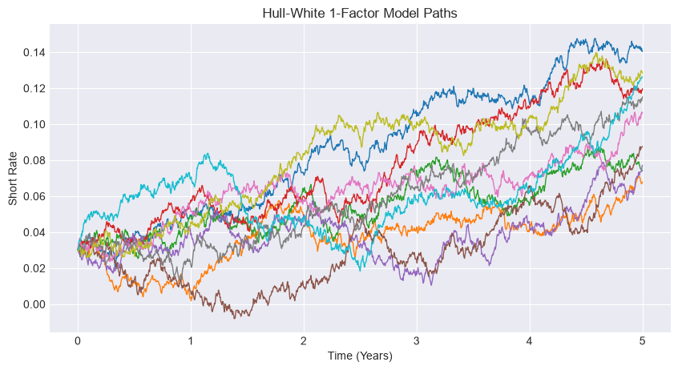

```python
# 1. Hull-White 1-Factor Model
a = 0.1
sigma = 0.02


def theta(t):
    return 0.01 + 0.005 * t


r0 = 0.03
T = 5.0

hw1f = HullWhite1FModel(a, sigma, theta)
mc_hw1f = MonteCarloEngine(hw1f, n_paths=100, n_steps=252 * 5, seed=42)

paths_hw1f = mc_hw1f.simulate_paths(r0, T)
time_grid = np.linspace(0, T, mc_hw1f.n_steps + 1)

plt.figure(figsize=(10, 5))
plt.plot(time_grid, paths_hw1f[:, :10], lw=1)
plt.title("Hull-White 1-Factor Model Paths")
plt.xlabel("Time (Years)")
plt.ylabel("Short Rate")
plt.show()
```

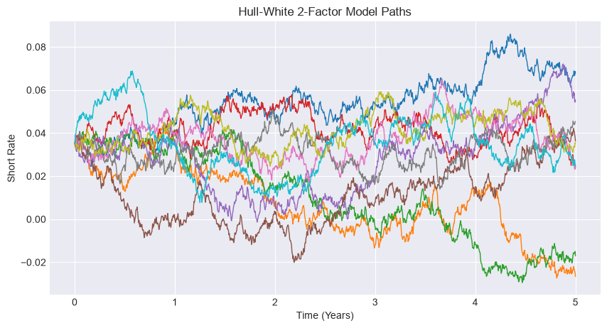

```python
# 2. Hull-White 2-Factor Model
a, b = 0.1, 0.2
sigma1, sigma2 = 0.02, 0.01
rho = -0.3


def phi(t):
    return 0.02


x0, y0 = 0.01, 0.005
r0_hw2f = (x0, y0)

hw2f = HullWhite2FModel(a, b, sigma1, sigma2, rho, phi)
mc_hw2f = MonteCarloEngine(hw2f, n_paths=100, n_steps=252 * 5, seed=42)

paths_hw2f = mc_hw2f.simulate_paths(r0_hw2f, T)

plt.figure(figsize=(10, 5))
plt.plot(time_grid, paths_hw2f[:, :10], lw=1)
plt.title("Hull-White 2-Factor Model Paths")
plt.xlabel("Time (Years)")
plt.ylabel("Short Rate")
plt.show()
```

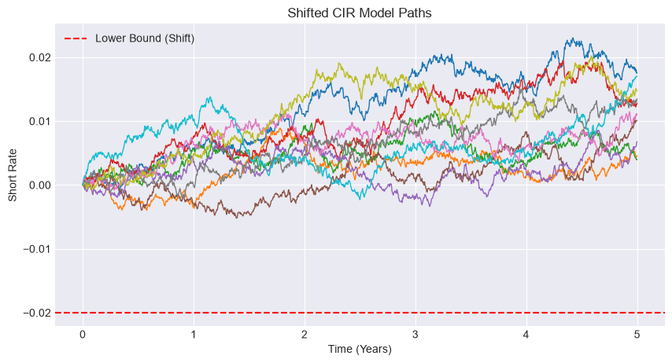

```python
# 3. Shifted CIR Model
a, b, sigma, shift = 0.2, 0.04, 0.03, -0.02
r0 = 0.00

shifted_cir = ShiftedCIRModel(a, b, sigma, shift)
mc_scir = MonteCarloEngine(shifted_cir, n_paths=100, n_steps=252 * 5, seed=42)

paths_scir = mc_scir.simulate_paths(r0, T)

plt.figure(figsize=(10, 5))
plt.plot(time_grid, paths_scir[:, :10], lw=1)
plt.axhline(shift, color="red", linestyle="--", label="Lower Bound (Shift)")
plt.title("Shifted CIR Model Paths")
plt.xlabel("Time (Years)")
plt.ylabel("Short Rate")
plt.legend()
plt.show()
```

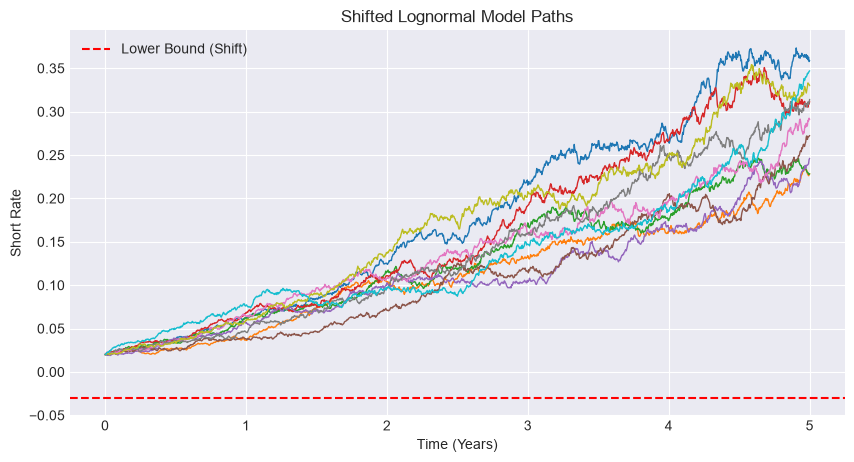

```python
# 4. Shifted Lognormal Model
a, theta_sl, sigma, shift = 0.2, 0.01, 0.15, -0.03
r0 = 0.02

shifted_lognorm = ShiftedLognormalModel(a, theta_sl, sigma, shift)
mc_sln = MonteCarloEngine(shifted_lognorm, n_paths=100, n_steps=252 * 5, seed=42)

paths_sln = mc_sln.simulate_paths(r0, T)

plt.figure(figsize=(10, 5))
plt.plot(time_grid, paths_sln[:, :10], lw=1)
plt.axhline(shift, color="red", linestyle="--", label="Lower Bound (Shift)")
plt.title("Shifted Lognormal Model Paths")
plt.xlabel("Time (Years)")
plt.ylabel("Short Rate")
plt.legend()
plt.show()
```

```python
# 5. Zero-Coupon Bond Pricing Comparison
T_pricing = 2.0
print(f"Pricing 2-year ZCB:\n")

hw1f_price = hw1f.zcb_price(r0, 0.0, T_pricing)
print(f"HW1F Analytic Price: {hw1f_price:.6f}")

hw2f_price = hw2f.zcb_price(x0, y0, 0.0, T_pricing)
print(f"HW2F Analytic Price: {hw2f_price:.6f}")

scir_price = shifted_cir.zcb_price(r0, T_pricing)
print(f"Shifted CIR Analytic Price: {scir_price:.6f}")

mc_sln_price = mc_sln.price_zcb(r0, T_pricing)
print(f"Shifted Lognormal MC Price: {mc_sln_price:.6f}")
```

```
Pricing 2-year ZCB:

HW1F Analytic Price: 0.940945
HW2F Analytic Price: 0.936189
Shifted CIR Analytic Price: 0.960824
Shifted Lognormal MC Price: 0.888555
```

# Module 7: Credit Derivatives Verification

This notebook verifies the ISDA Standard CDS model and Merton Jump-Diffusion model implementation.

```python
import sys
import os
import datetime

sys.path.insert(0, os.path.abspath(".."))

from src.credit.cds import isda_upfront_charge, isda_par_spread
from src.credit.structural import MertonJumpDiffusionModel
from src.utils.plotting import set_theme

set_theme()
```

## ISDA Standard CDS Model

Verify exact IMM dates upfront/spread conversion.

```python
valuation_date = datetime.date(2023, 9, 15)
effective_date = datetime.date(2023, 9, 16)
maturity_date = datetime.date(2028, 12, 20)  # 5-year CDS


def curve(t):
    return 0.03  # flat 3% curve


recovery_rate = 0.40
notional = 10_000_000
standard_coupon = 0.01
quoted_par_spread = 0.0120

upfront = isda_upfront_charge(
    valuation_date,
    effective_date,
    maturity_date,
    quoted_par_spread,
    standard_coupon,
    curve,
    recovery_rate,
    notional,
)
print(f"Quoted Par Spread: {quoted_par_spread * 10000:.0f} bps")
print(f"Standard Coupon: {standard_coupon * 10000:.0f} bps")
print(f"Upfront Charge (USD): ${upfront:,.2f}")

implied_par = isda_par_spread(
    valuation_date,
    effective_date,
    maturity_date,
    upfront,
    standard_coupon,
    curve,
    recovery_rate,
    notional,
)
print(f"Implied Par Spread: {implied_par * 10000:.2f} bps")
```

```
Quoted Par Spread: 120 bps
Standard Coupon: 100 bps
Upfront Charge (USD): $93,140.45
Implied Par Spread: 120.00 bps
```

## Merton Jump-Diffusion Model

Calculate equity and debt value under the jump-diffusion model.

```python
mjd = MertonJumpDiffusionModel(
    V=100_000_000.0,
    D=80_000_000.0,
    T=1.0,
    r=0.03,
    sigma_V=0.20,
    lambda_j=0.5,
    mu_j=-0.1,
    sigma_j=0.3,
)
equity = mjd.equity_value()
debt = mjd.debt_value()

print(f"Asset Value: ${mjd.V:,.2f}")
print(f"Face Value of Debt: ${mjd.D:,.2f}")
print(f"MJD Equity Value: ${equity:,.2f}")
print(f"MJD Debt Value: ${debt:,.2f}")
```

```
Asset Value: $100,000,000.00
Face Value of Debt: $80,000,000.00
MJD Equity Value: $25,216,061.71
MJD Debt Value: $74,783,938.29
```

# Module 7: Advanced Curve Dynamics & Stochastic Simulation

In this module, we transition from deterministic pricing to probabilistic models. We will:

1. Fetch 10 years of historical Treasury yield curve data.
2. Perform **Principal Component Analysis (PCA)** to decompose the curve movements into empirical factors (Level, Steepness, Curvature).
3. **Calibrate** stochastic short-rate models (Vasicek and CIR) to historical rates.
4. Run a **Monte Carlo Engine** to simulate thousands of future yield curve paths.

```python
%load_ext autoreload
%autoreload 2

import sys
import os

sys.path.insert(0, os.path.abspath(".."))
print("CWD:", os.getcwd())
print("SYS.PATH:", sys.path)

import datetime  # noqa: E402
import numpy as np  # noqa: E402
import pandas as pd  # noqa: E402
import matplotlib.pyplot as plt  # noqa: E402

from src.data.fred import FredFetcher  # noqa: E402
from src.curve.pca import YieldCurvePCA  # noqa: E402
from src.models.stochastic import CIRModel  # noqa: E402
from src.models.calibration import calibrate_vasicek, calibrate_cir  # noqa: E402
from src.models.monte_carlo import MonteCarloEngine  # noqa: E402
from src.utils.plotting import set_theme  # noqa: E402

set_theme()
```

```
CWD: /Users/mukundankit/Documents/Finance/bond_modelling/notebooks
SYS.PATH: ['/Users/mukundankit/Documents/Finance/bond_modelling', '/Users/mukundankit/.local/share/uv/python/cpython-3.12.13-macos-aarch64-none/lib/python312.zip', '/Users/mukundankit/.local/share/uv/python/cpython-3.12.13-macos-aarch64-none/lib/python3.12', '/Users/mukundankit/.local/share/uv/pytho…
```

## 1. Fetching Historical Treasury Data

```python
# Fetch data (cached if previously run)
fetcher = FredFetcher()
end_date = datetime.date(2023, 12, 31)
start_date = datetime.date(2013, 1, 1)

# In practice, fetching 10 years of daily curves from the Treasury API directly can take a while
# and might hit rate limits. To keep this notebook fast, we'll fetch end-of-month curves.

dates = pd.date_range(start_date, end_date, freq="ME").date
curves = []
valid_dates = []

for d in dates:
    try:
        curve = fetcher.fetch_yield_curve(d)
        curves.append(curve)
        valid_dates.append(d)
    except Exception:
        # Holiday or weekend
        pass

df_yields = pd.DataFrame(curves, index=valid_dates)
df_yields = df_yields.dropna(
    axis=1, thresh=len(df_yields) * 0.9
)  # Drop if more than 10% missing
df_yields = df_yields.interpolate(method="linear", limit_direction="both")
df_yields = df_yields.bfill().ffill()  # Just in case interpolation misses edges
print("Yields shape:", df_yields.shape)
df_yields.head()
```

[output not shown]

[output not shown]

[output not shown]

[output not shown]

[output not shown]

[output not shown]

[output not shown]

[output not shown]

[output not shown]

[output not shown]

[output not shown]

[output not shown]

[output not shown]

[output not shown]

[output not shown]

[output not shown]

[output not shown]

```
Yields shape: (115, 6)
```

|  | 0.25 | 1.00 | 2.00 | 5.00 | 10.00 | 30.00 |
| --- | --- | --- | --- | --- | --- | --- |
| 2013-01-31 | 0.0007 | 0.0015 | 0.0027 | 0.0088 | 0.0202 | 0.0317 |
| 2013-02-28 | 0.0011 | 0.0017 | 0.0025 | 0.0077 | 0.0189 | 0.0310 |
| 2013-03-31 | 0.0007 | 0.0014 | 0.0025 | 0.0077 | 0.0187 | 0.0310 |
| 2013-04-30 | 0.0005 | 0.0011 | 0.0022 | 0.0068 | 0.0170 | 0.0288 |
| 2013-05-31 | 0.0004 | 0.0014 | 0.0030 | 0.0105 | 0.0216 | 0.0330 |

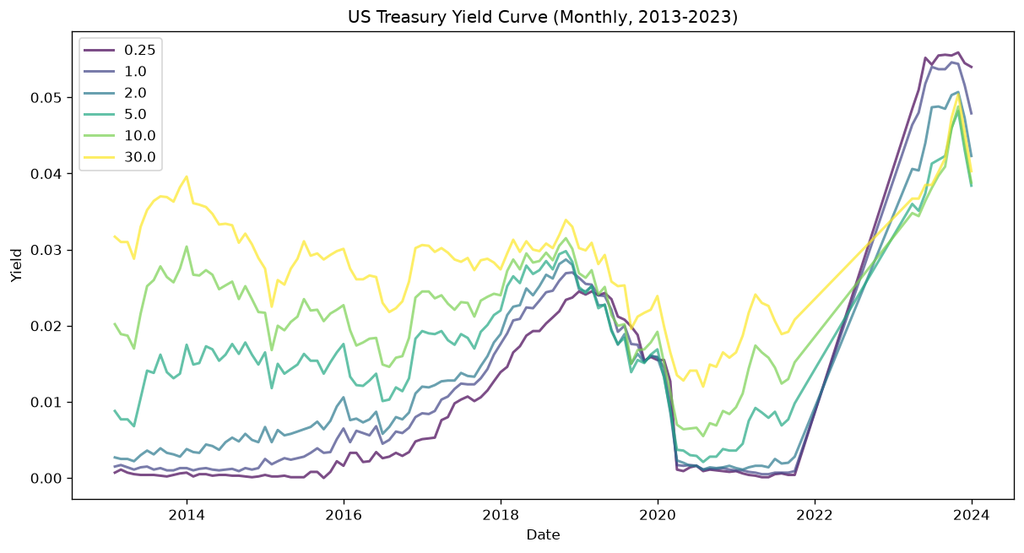

```python
df_yields.plot(figsize=(12, 6), colormap="viridis", alpha=0.7)
plt.title("US Treasury Yield Curve (Monthly, 2013-2023)")
plt.ylabel("Yield")
plt.xlabel("Date")
plt.show()
```

## 2. Principal Component Analysis (PCA)

We will decompose the historical yield curve to extract the latent factors driving its movement.

```python
pca = YieldCurvePCA(n_components=3)
pca.fit(df_yields)

print(f"Explained Variance Ratio: {pca.explained_variance_ratio_}")
print(f"Total Explained Variance: {np.sum(pca.explained_variance_ratio_):.4f}")
```

```
Explained Variance Ratio: [0.90875095 0.08158053 0.00835382]
Total Explained Variance: 0.9987
```

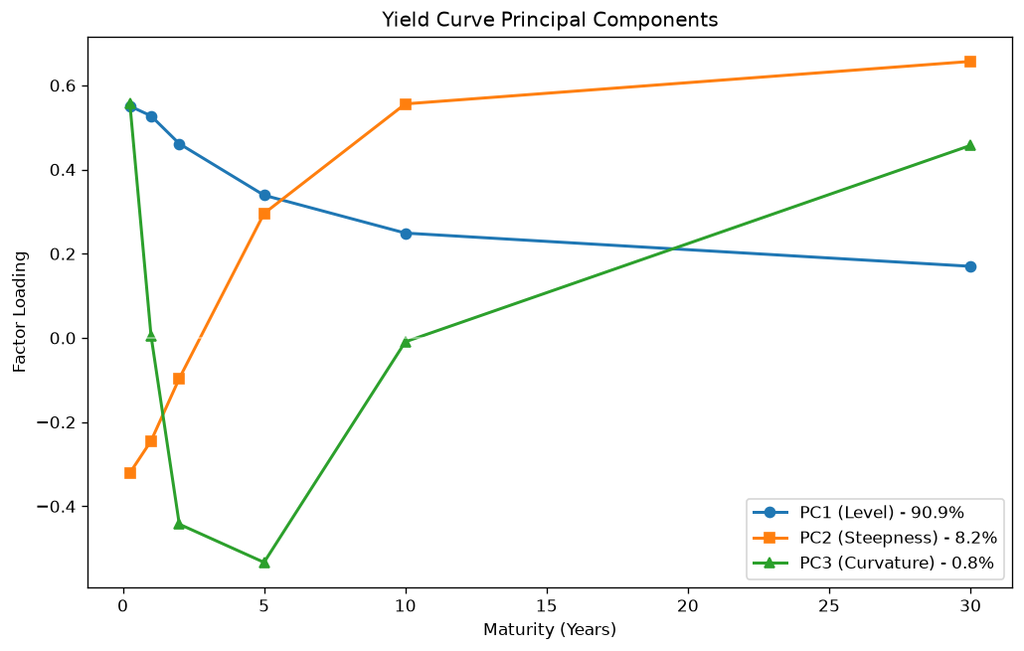

```python
# Plot the principal components (factor loadings)
maturities = df_yields.columns.values

plt.figure(figsize=(10, 6))
plt.plot(
    maturities,
    pca.components_[0],
    marker="o",
    label=f"PC1 (Level) - {pca.explained_variance_ratio_[0]:.1%}",
)
plt.plot(
    maturities,
    pca.components_[1],
    marker="s",
    label=f"PC2 (Steepness) - {pca.explained_variance_ratio_[1]:.1%}",
)
plt.plot(
    maturities,
    pca.components_[2],
    marker="^",
    label=f"PC3 (Curvature) - {pca.explained_variance_ratio_[2]:.1%}",
)

plt.axhline(0, color="white", linewidth=1, alpha=0.5)
plt.title("Yield Curve Principal Components")
plt.xlabel("Maturity (Years)")
plt.ylabel("Factor Loading")
plt.legend()
plt.show()
```

## 3. Calibrating Stochastic Models (Vasicek and CIR)

Let's calibrate the Vasicek and CIR models to the 1-Year Treasury rate.

```python
# 1-Year Treasury Yields
r_1y = df_yields[1.0].values

# Calibrate Vasicek
dt = 1 / 12  # Monthly data
a_v, b_v, sigma_v = calibrate_vasicek(r_1y, dt)
print(
    f"Vasicek Calibration -> Speed (a): {a_v:.4f}, Mean (b): {b_v:.4f}, Volatility (sigma): {sigma_v:.4f}"
)

# Calibrate CIR
a_c, b_c, sigma_c = calibrate_cir(r_1y, dt)
print(
    f"CIR Calibration     -> Speed (a): {a_c:.4f}, Mean (b): {b_c:.4f}, Volatility (sigma): {sigma_c:.4f}"
)
```

```
Vasicek Calibration -> Speed (a): 0.2721, Mean (b): 0.0296, Volatility (sigma): 0.0154
CIR Calibration     -> Speed (a): 0.8563, Mean (b): 0.0174, Volatility (sigma): 0.4875
```

## 4. Monte Carlo Simulation

Using the calibrated CIR model, we will simulate 1,000 future paths of the 1-year rate over the next 5 years.

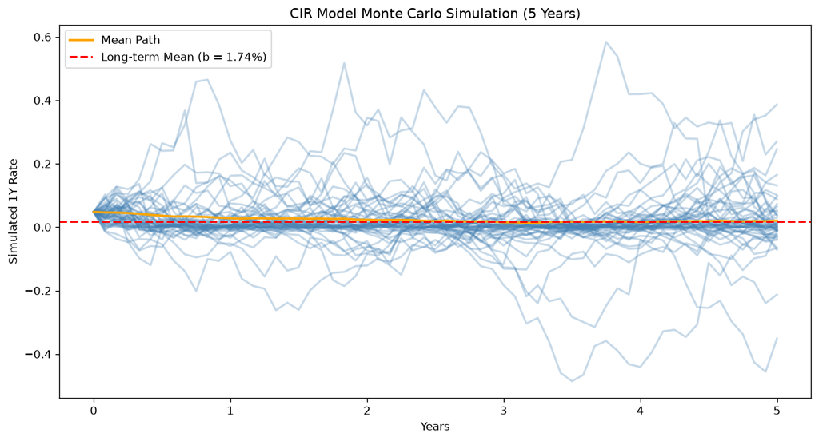

```python
# Initialize models
cir = CIRModel(a_c, b_c, sigma_c)

# Simulate 1,000 paths over 5 years
mc_engine = MonteCarloEngine(
    cir, n_paths=1000, n_steps=60, seed=42
)  # 60 months = 5 years
r0 = r_1y[-1]  # Starting rate (latest observation)

paths = mc_engine.simulate_paths(r0=r0, T=5.0)

plt.figure(figsize=(12, 6))
# Plot first 50 paths to avoid crowding
plt.plot(np.linspace(0, 5, 61), paths[:, :50], alpha=0.3, color="steelblue")
plt.plot(
    np.linspace(0, 5, 61),
    np.mean(paths, axis=1),
    color="orange",
    linewidth=2,
    label="Mean Path",
)
plt.axhline(b_c, color="red", linestyle="--", label=f"Long-term Mean (b = {b_c:.2%})")

plt.title("CIR Model Monte Carlo Simulation (5 Years)")
plt.xlabel("Years")
plt.ylabel("Simulated 1Y Rate")
plt.legend()
plt.show()
```

# Module 8: Interest Rate Derivatives Pricing

```python
import sys

sys.path.append("/Users/mukundankit/Documents/Finance/bond_modelling")
import numpy as np
import matplotlib.pyplot as plt

from src.curve.nelson_siegel import NelsonSiegelCurve
from src.models.stochastic import VasicekModel
from src.derivatives.swap import InterestRateSwap, swap_rate, swap_pv
from src.derivatives.cap_floor import Cap, Floor, cap_floor_pv, cap_floor_bachelier
from src.derivatives.swaption import (
    Swaption,
    price_swaption_jamshidian,
    price_swaption_bachelier,
)
from src.utils.plotting import set_theme

set_theme()
```

## 1. Interest Rate Swap (IRS) & Par Curve

First, we calibrate a Nelson-Siegel curve and compute the Par Swap Curve across multiple tenors. The Par Swap Curve shows the fixed rate required for a newly initiated swap to have exactly 0 present value.

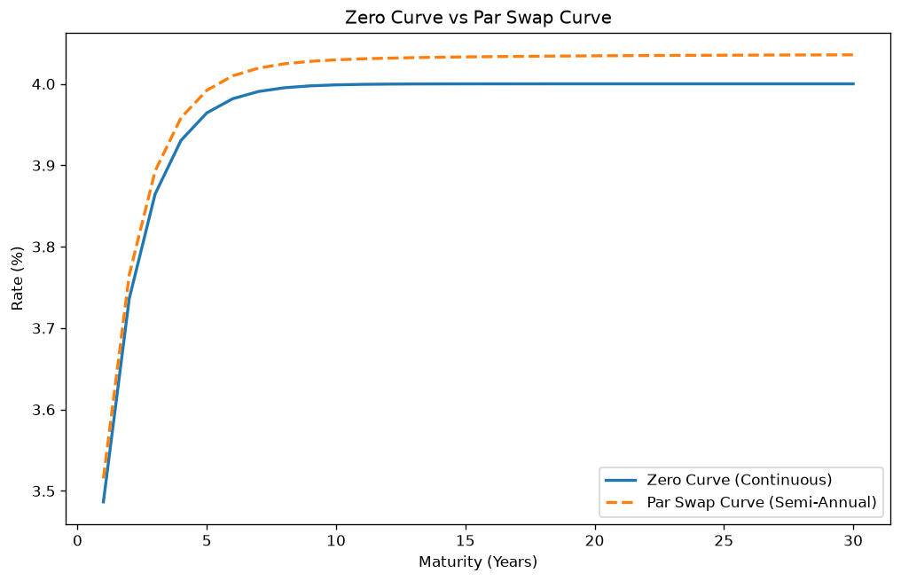

```python
curve = NelsonSiegelCurve(beta0=0.04, beta1=-0.01, beta2=0.01, tau=1.5)

tenors = np.linspace(1, 30, 30)
par_rates = []
zero_rates = []

for T in tenors:
    swap = InterestRateSwap(notional=10_000_000, fixed_rate=0.0, tenor=T, freq=2)
    par_rates.append(swap_rate(swap, curve))
    zero_rates.append(curve(T))

plt.figure(figsize=(10, 6))
plt.plot(
    tenors, np.array(zero_rates) * 100, label="Zero Curve (Continuous)", linewidth=2
)
plt.plot(
    tenors,
    np.array(par_rates) * 100,
    label="Par Swap Curve (Semi-Annual)",
    linestyle="--",
    linewidth=2,
)
plt.xlabel("Maturity (Years)")
plt.ylabel("Rate (%)")
plt.title("Zero Curve vs Par Swap Curve")
plt.legend()
plt.show()
```

## 2. Interest Rate Caps and Floors

We price caps and floors across a range of strikes. This demonstrates the non-linear optionality inherent in these instruments.

We will use a flat continuous zero curve to isolate the effect of strikes and price them using both Vasicek and Bachelier's Model.

[figure not shown]

```python
model = VasicekModel(a=0.1, b=0.04, sigma=0.015)
r_t = 0.04


def zcb_curve(t):
    if t == 0:
        return r_t
    return -float(np.log(model.zcb_price(r_t, t))) / t


strikes = np.linspace(0.01, 0.07, 50)
vol = 0.20  # 20% lognormal volatility

pv_caps_v, pv_floors_v = [], []
pv_caps_b, pv_floors_b = [], []

for K in strikes:
    cap = Cap(notional=10_000_000, strike=K, tenor=5, freq=2)
    floor = Floor(notional=10_000_000, strike=K, tenor=5, freq=2)

    # Vasicek Prices
    pv_caps_v.append(cap_floor_pv(cap, model, r_t))
    pv_floors_v.append(cap_floor_pv(floor, model, r_t))

    # Bachelier Prices
    pv_caps_b.append(cap_floor_bachelier(cap, zcb_curve, vol))
    pv_floors_b.append(cap_floor_bachelier(floor, zcb_curve, vol))

fig, (ax1, ax2) = plt.subplots(1, 2, figsize=(14, 5))

# Plot 1: Vasicek Prices
ax1.plot(strikes * 100, pv_caps_v, label="Cap PV")
ax1.plot(strikes * 100, pv_floors_v, label="Floor PV")
ax1.axvline(r_t * 100, color="grey", linestyle=":", label="ATM Rate (4%)")
ax1.set_title("Cap and Floor PVs vs Strike (Vasicek Model)")
ax1.set_xlabel("Strike (%)")
ax1.set_ylabel("Present Value ($)")
ax1.legend()

# Plot 2: Bachelier Model Prices
ax2.plot(strikes * 100, pv_caps_b, label="Cap PV", color="C2")
ax2.plot(strikes * 100, pv_floors_b, label="Floor PV", color="C3")
ax2.axvline(r_t * 100, color="grey", linestyle=":", label="ATM Rate (4%)")
ax2.set_title("Cap and Floor PVs vs Strike (Bachelier's Model)")
ax2.set_xlabel("Strike (%)")
ax2.set_ylabel("Present Value ($)")
ax2.legend()

plt.tight_layout()
plt.show()
```

### Cap-Floor Parity Validation

By Put-Call parity, `Cap - Floor = Forward Payer Swap`. We will verify this relationship computationally.

```python
# Verify parity at K=0.04
strike = 0.04
cap = Cap(notional=10_000_000, strike=strike, tenor=5, freq=2)
floor = Floor(notional=10_000_000, strike=strike, tenor=5, freq=2)
swap_cf = InterestRateSwap(notional=10_000_000, fixed_rate=strike, tenor=5, freq=2)

v_cap = cap_floor_pv(cap, model, r_t)
v_floor = cap_floor_pv(floor, model, r_t)
v_swap = swap_pv(swap_cf, zcb_curve, position="payer")

print(f"Parity Difference (Vasicek): ${(v_cap - v_floor) - v_swap:,.6f}")

b_cap = cap_floor_bachelier(cap, zcb_curve, vol)
b_floor = cap_floor_bachelier(floor, zcb_curve, vol)
print(f"Parity Difference (Bachelier):   ${(b_cap - b_floor) - v_swap:,.6f}")
```

```
Parity Difference (Vasicek): $-0.000000
Parity Difference (Bachelier):   $0.000000
```

## 3. European Swaptions & Volatility Sensitivity

[figure not shown]

```python
swap_underlying = InterestRateSwap(
    notional=10_000_000, fixed_rate=0.04, tenor=7, freq=2
)
payer_swaption = Swaption(swap=swap_underlying, expiry=2.0, option_type="payer")
receiver_swaption = Swaption(swap=swap_underlying, expiry=2.0, option_type="receiver")

vols = np.linspace(0.05, 0.50, 20)
pv_payer_sw, pv_receiver_sw = [], []

for v in vols:
    pv_payer_sw.append(price_swaption_bachelier(payer_swaption, zcb_curve, v))
    pv_receiver_sw.append(price_swaption_bachelier(receiver_swaption, zcb_curve, v))

plt.figure(figsize=(10, 6))
plt.plot(vols * 100, pv_payer_sw, label="Payer Swaption (Bachelier)")
plt.plot(vols * 100, pv_receiver_sw, label="Receiver Swaption (Bachelier)")

# Add Vasicek Baseline (Independent of Bachelier Vol)
v_payer = price_swaption_jamshidian(payer_swaption, model, r_t)
v_recv = price_swaption_jamshidian(receiver_swaption, model, r_t)
plt.axhline(
    v_payer,
    color="C0",
    linestyle="--",
    label="Payer Swaption (Vasicek Implied)",
    alpha=0.5,
)
plt.axhline(
    v_recv,
    color="C1",
    linestyle="--",
    label="Receiver Swaption (Vasicek Implied)",
    alpha=0.5,
)

plt.xlabel("Implied Bachelier Volatility (%)")
plt.ylabel("Present Value ($)")
plt.title("2y5y Swaption PV vs Volatility")
plt.legend()
plt.show()
```

# 08 - Swaps Verification

This notebook demonstrates the Multi-Curve Integration and AAD framework for Interest Rate Swaps.

```python
import sys
import os

sys.path.append(os.path.abspath(".."))

from src.derivatives.swap import InterestRateSwap, swap_pv
from src.curve.nelson_siegel import NelsonSiegelCurve
from src.derivatives.aad import Dual
```

## 1. Multi-Curve Pricing

```python
# Discount and Forward curves
discount_curve = NelsonSiegelCurve(0.03, 0.0, 0.0, 1.0)
forward_curve = NelsonSiegelCurve(0.04, 0.0, 0.0, 1.0)

swap = InterestRateSwap(notional=1e6, fixed_rate=0.035, tenor=5.0, freq=2)

pv = swap_pv(swap, discount_curve, forward_curve, position="receiver")
print(f"Swap PV (Multi-Curve): {float(pv):.2f}")
```

```
Swap PV (Multi-Curve): -24897.34
```

## 2. AAD Exact Greeks

```python
# Using Dual numbers to get exact sensitivities (Rho) to parallel curve shifts
bump_d = Dual(0.0)
bump_f = Dual(0.0)


def bumped_discount(t):
    # AAD-enabled discount curve wrapper
    return 0.03 + bump_d


def bumped_forward(t):
    return 0.04 + bump_f


pv_dual = swap_pv(swap, bumped_discount, bumped_forward, position="receiver")
pv_dual.backward()

print(f"PV: {float(pv_dual):.2f}")
print(f"DV01 w.r.t Discount Curve: {bump_d.adjoint:.2f}")
print(f"DV01 w.r.t Forward Curve: {bump_f.adjoint:.2f}")
```

```
PV: -24897.34
DV01 w.r.t Discount Curve: 66927.75
DV01 w.r.t Forward Curve: -4701425.98
```

# Module 9: Credit Risk & CDS Verification

## Hazard Rate Calibration

```python
import sys
import os

sys.path.insert(0, os.path.abspath(".."))

import numpy as np
from src.credit.reduced_form import calibrate_hazard_rates  # noqa: E402
from src.credit.structural import (  # noqa: E402
    merton_distance_to_default,
    merton_probability_of_default,
)
from src.utils.plotting import set_theme  # noqa: E402

set_theme()

# Reduced Form Model: Hazard Rate Calibration
maturities = np.array([1, 3, 5, 7, 10])
spreads = np.array([0.0050, 0.0075, 0.0100, 0.0125, 0.0150])  # 50 to 150 bps
recovery_rate = 0.40

hazard_rates = calibrate_hazard_rates(maturities, spreads, recovery_rate)
print("Calibrated Hazard Rates:")
for m, h in zip(maturities, hazard_rates):
    print(f"{m}Y: {h:.4%}")
```

```
Calibrated Hazard Rates:
1Y: 0.8347%
3Y: 1.4719%
5Y: 2.3496%
7Y: 3.2810%
10Y: 3.7922%
```

## Merton Structural Model

```python
# Structural Model (Merton)
asset_value = 100_000_000
debt_face_value = 80_000_000
asset_volatility = 0.25
risk_free_rate = 0.03
time_to_maturity = 1.0

dd = merton_distance_to_default(
    asset_value, debt_face_value, asset_volatility, risk_free_rate, time_to_maturity
)
pd_merton = merton_probability_of_default(dd)

print(f"Distance to Default: {dd:.4f}")
print(f"1-Year Probability of Default: {pd_merton:.4%}")
```

```
Distance to Default: 0.8876
1-Year Probability of Default: 18.7385%
```

# 09 - Options Verification

```python
import sys
import os

sys.path.append(os.path.abspath(".."))

import numpy as np
from src.derivatives.swaption import Swaption, price_swaption_bachelier
from src.derivatives.swap import InterestRateSwap
from src.curve.nelson_siegel import NelsonSiegelCurve
from src.derivatives.aad import Dual
```

## 1. Bachelier Swaption Pricing

```python
discount_curve = NelsonSiegelCurve(0.04, 0.0, 0.0, 1.0)
swap = InterestRateSwap(notional=1e6, fixed_rate=0.04, tenor=5.0, freq=2)
swaption = Swaption(swap, expiry=2.0, option_type="payer")

pv = price_swaption_bachelier(swaption, discount_curve, vol=0.0050)
print(f"Swaption PV (Bachelier): {float(pv):.2f}")
```

```
Swaption PV (Bachelier): 7820.29
```

## 2. SABR Swaption Pricing

```python
sabr_params = {"alpha": 0.0050, "rho": -0.2, "nu": 0.3}
pv_sabr = price_swaption_bachelier(swaption, discount_curve, sabr_params=sabr_params)
print(f"Swaption PV (SABR): {float(pv_sabr):.2f}")
```

```
Swaption PV (SABR): 7941.39
```

## 3. AAD Exact Vega and Delta

```python
# Using Dual numbers to get exact Greeks
from src.derivatives.bachelier import bachelier_formula

fwd = Dual(0.04)
strike = Dual(0.04)
t_exp = Dual(2.0)
vol = Dual(0.0050)
df = Dual(np.exp(-0.04 * 2.0))

px = bachelier_formula(fwd, strike, t_exp, vol, df, is_call=True)
px.backward()

print(f"Option Price: {float(px):.6f}")
print(f"Delta: {fwd.adjoint:.6f}")
print(f"Vega: {vol.adjoint:.6f}")
```

```
Option Price: 0.002604
Delta: 0.461558
Vega: 0.520813
```

# Module 10: MBS & Prepayment Verification

## PSA Prepayment Models

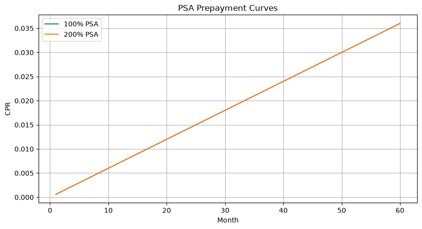

```python
import sys
import os

sys.path.insert(0, os.path.abspath(".."))

import numpy as np
from src.mbs.prepayment import cpr_to_smm, psa_to_cpr  # noqa: E402
from src.mbs.pass_through import project_cash_flows  # noqa: E402
import matplotlib.pyplot as plt

# PSA Model
months = np.arange(1, 61)
cpr_100 = [psa_to_cpr(m, 100) for m in months]
cpr_200 = [psa_to_cpr(m, 200) for m in months]

plt.figure(figsize=(10, 5))
plt.plot(months, cpr_100, label="100% PSA")
plt.plot(months, cpr_200, label="200% PSA")
plt.title("PSA Prepayment Curves")
plt.xlabel("Month")
plt.ylabel("CPR")
plt.legend()
plt.grid(True)
plt.show()
```

## Pass-Through Cash Flows

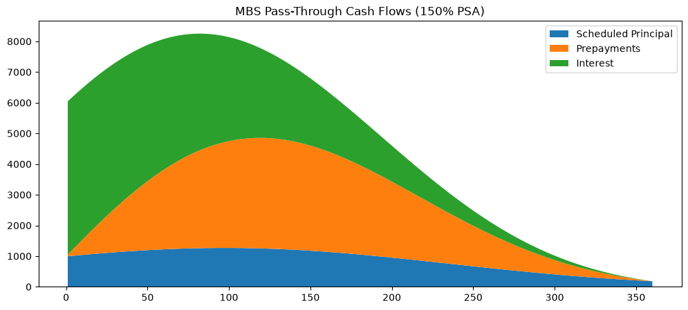

```python
# Pass-Through Cash Flows
balance = 1_000_000
wac = 0.06  # Weighted Average Coupon
term = 360  # 30-year
cpr_curve = [psa_to_cpr(m, 150) for m in range(1, term + 1)]
smm_curve = [cpr_to_smm(cpr) for cpr in cpr_curve]

cashflows = project_cash_flows(balance, wac, term, smm_curve)

# Plot Cashflows
plt.figure(figsize=(12, 5))
plt.stackplot(
    range(1, term + 1),
    cashflows["scheduled_principal"],
    cashflows["prepayment"],
    cashflows["interest"],
    labels=["Scheduled Principal", "Prepayments", "Interest"],
)
plt.legend(loc="upper right")
plt.title("MBS Pass-Through Cash Flows (150% PSA)")
plt.show()
```

## Richard-Roll Prepayment Model

Demonstrating the new stochastic/behavioral prepayment modeling.

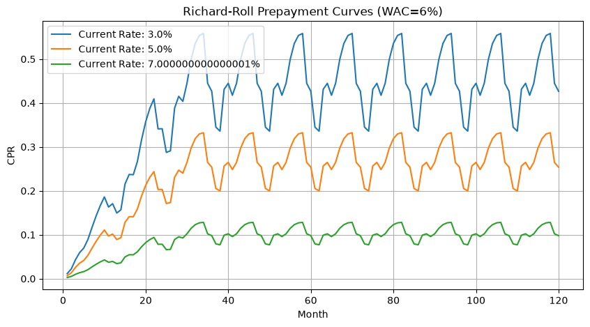

```python
import numpy as np
import matplotlib.pyplot as plt
from src.mbs.prepayment import richard_roll_cpr

months = np.arange(1, 121)
wac = 0.06
rates = [0.03, 0.05, 0.07]  # Different current rates to show refinancing incentive

plt.figure(figsize=(10, 5))
for r in rates:
    cpr_curve = [
        richard_roll_cpr(wac, r, m, m % 12 + 1, pool_factor=1.0) for m in months
    ]
    plt.plot(months, cpr_curve, label=f"Current Rate: {r * 100}%")

plt.title("Richard-Roll Prepayment Curves (WAC=6%)")
plt.xlabel("Month")
plt.ylabel("CPR")
plt.legend()
plt.grid(True)
plt.show()
```

## Monte Carlo OAS using Hull-White

Pricing the prepayment option using stochastic generated paths.

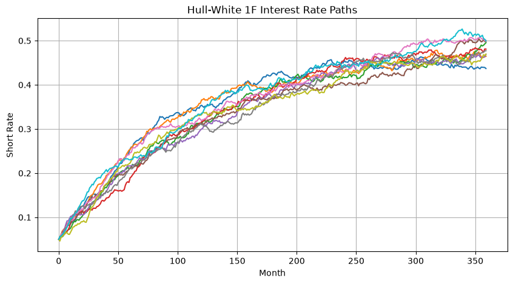

```
Calculated Monte Carlo OAS: -1437.11 bps
```

```python
from src.mbs.oas import generate_hw1f_paths, calculate_oas
from src.mbs.pass_through import project_cash_flows

# Generate HW1F paths
n_paths = 100
term = 360
r0 = 0.05
a = 0.1
sigma = 0.01

rate_paths = generate_hw1f_paths(r0, a, sigma, n_paths, term, 1.0 / 12.0, r0)

plt.figure(figsize=(10, 5))
for i in range(10):
    plt.plot(rate_paths[i, :])
plt.title("Hull-White 1F Interest Rate Paths")
plt.xlabel("Month")
plt.ylabel("Short Rate")
plt.grid(True)
plt.show()

# Calculate OAS
balance = 100000
wac = 0.06


# We'll use a dynamic prepayment model (richard-roll)
def dynamic_smm_hw(rate_path, wac_val):
    # rate_path is an array of length term
    def smm_func(t, pool_factor):
        # We need the rate at time t
        current_rate = rate_path[t] if t < len(rate_path) else rate_path[-1]
        cpr = richard_roll_cpr(wac_val, current_rate, t + 1, (t % 12) + 1, pool_factor)
        return 1.0 - (1.0 - cpr) ** (1.0 / 12.0)

    return smm_func


# To find OAS, we need a price first. Let's assume price = 101000
price = 101000
oas = calculate_oas(price, balance, wac, term, rate_paths, dynamic_smm_hw)
print(f"Calculated Monte Carlo OAS: {oas * 10000:.2f} bps")
```

# Module 11: Advanced Term Structure & Trees

## Hull-White Lattice

```python
import sys
import os

sys.path.insert(0, os.path.abspath(".."))

from src.trees.hull_white import HullWhiteTree  # noqa: E402

# Trinomial Tree Setup
num_steps = 10
time_step = 0.5
sigma = 0.015
a = 0.1  # mean reversion

hw_tree = HullWhiteTree(
    a=a,
    sigma=sigma,
    time_step=time_step,
    num_steps=num_steps,
    zero_curve=lambda _: 0.03,
)
print("Hull-White Tree generated successfully.")
print(f"Number of nodes at step 5: {len(hw_tree.get_nodes_at_step(5))}")
```

```
Hull-White Tree generated successfully.
Number of nodes at step 5: 9
```

## Binomial Interest Rate Tree (Module 45)

This section demonstrates the recombining log-normal binomial tree for short rate modeling and zero-coupon bond pricing via backward induction.

```python
from src.trees.binomial import BinomialTree

# Create a 5-step binomial tree
volatility = 0.20  # 20% volatility
time_step = 1.0  # 1-year step
r0 = 0.05  # 5% initial short rate

tree = BinomialTree(r0=r0, volatility=volatility, time_step=time_step, periods=5)

# Calculate theoretical ZCB price for a face value of $1.0
zcb_price = tree.price_zero_coupon_bond(face_value=1.0)
print(f"Zero-Coupon Bond Price (5-year, r0=5%): ${zcb_price * 100:.2f}")

# Display rates at step 2
rates = tree.build_tree()
rates_step_2 = rates[2]
print(f"Rates at Step 2: {[f'{r * 100:.2f}%' for r in rates_step_2]}")
```

```
Zero-Coupon Bond Price (5-year, r0=5%): $77.75
Rates at Step 2: ['3.35%', '5.00%', '7.46%']
```

# Module 12: Inflation-Linked Bonds

## TIPS Pricing & Real Yields

```python
import sys
import os

sys.path.insert(0, os.path.abspath(".."))

from src.inflation.curves import generate_real_curve  # noqa: E402
from src.inflation.tips import price_tips  # noqa: E402
import numpy as np

# Real vs Nominal
nominal_yields = np.array([0.04, 0.045, 0.05])
breakeven_inflation = np.array([0.02, 0.022, 0.025])
real_yields = generate_real_curve(nominal_yields, breakeven_inflation)

print("Nominal Yields:", nominal_yields)
print("Breakeven Inflation:", breakeven_inflation)
print("Implied Real Yields:", real_yields)

# TIPS Pricing
cpi_base = 250.0
cpi_current = 265.0
index_ratio = cpi_current / cpi_base

# Price of a TIPS bond
face_value = 1000
coupon_rate = 0.015  # Real coupon
maturity = 5
real_ytm = 0.01

price = price_tips(face_value, coupon_rate, maturity, real_ytm, index_ratio)
print(
    f"\nTIPS Price (Real YTM {real_ytm:.2%}, Index Ratio {index_ratio:.4f}): ${price:.2f}"
)
```

```
Nominal Yields: [0.04  0.045 0.05 ]
Breakeven Inflation: [0.02  0.022 0.025]
Implied Real Yields: [0.01960784 0.02250489 0.02439024]

TIPS Price (Real YTM 1.00%, Index Ratio 1.0600): $1085.79
```

# Module 12: Value at Risk (VaR) & Expected Shortfall with EVT

## Historical Simulation and EVT (Cornish-Fisher & POT)

```
Historical 99% VaR: $174,573.71
Historical 99% ES:  $247,940.23

Cornish-Fisher 99% VaR: $248,223.41
Cornish-Fisher 99% ES:  $377,615.28

Peaks-Over-Threshold 99% ES: $247,512.08
```

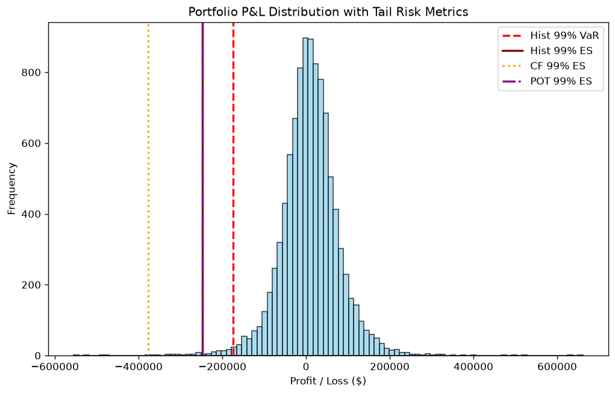

```python
import sys
import os

sys.path.insert(0, os.path.abspath(".."))

import numpy as np
import matplotlib.pyplot as plt
from src.portfolio.var import historical_var, historical_expected_shortfall
from src.portfolio.var import cornish_fisher_var, cornish_fisher_expected_shortfall
from src.portfolio.var import pot_expected_shortfall
from src.utils.plotting import set_theme

set_theme()

# Generate a synthetic historical P&L vector (fat-tailed distribution using Student-t)
np.random.seed(42)
pnl_historical = np.random.standard_t(df=4, size=10000) * 50000 + 10000

# Calculate Historical VaR & ES at 99% confidence
hist_var = historical_var(pnl_historical, 0.99)
hist_es = historical_expected_shortfall(pnl_historical, 0.99)

# Calculate Cornish-Fisher VaR & ES
cf_var = cornish_fisher_var(pnl_historical, 0.99)
cf_es = cornish_fisher_expected_shortfall(pnl_historical, 0.99)

# Calculate POT EVT Expected Shortfall
pot_es = pot_expected_shortfall(pnl_historical, 0.99)

print(f"Historical 99% VaR: ${hist_var:,.2f}")
print(f"Historical 99% ES:  ${hist_es:,.2f}\n")
print(f"Cornish-Fisher 99% VaR: ${cf_var:,.2f}")
print(f"Cornish-Fisher 99% ES:  ${cf_es:,.2f}\n")
print(f"Peaks-Over-Threshold 99% ES: ${pot_es:,.2f}")

# Plotting the P&L distribution
plt.figure(figsize=(10, 6))
plt.hist(pnl_historical, bins=100, color="skyblue", edgecolor="black", alpha=0.7)
plt.axvline(
    -hist_var, color="red", linestyle="dashed", linewidth=2, label=f"Hist 99% VaR"
)
plt.axvline(
    -hist_es, color="darkred", linestyle="solid", linewidth=2, label=f"Hist 99% ES"
)
plt.axvline(-cf_es, color="orange", linestyle="dotted", linewidth=2, label=f"CF 99% ES")
plt.axvline(
    -pot_es, color="purple", linestyle="dashdot", linewidth=2, label=f"POT 99% ES"
)

plt.title("Portfolio P&L Distribution with Tail Risk Metrics")
plt.xlabel("Profit / Loss ($)")
plt.ylabel("Frequency")
plt.legend()
plt.show()
```

## Full Revaluation VaR

```python
from src.portfolio.portfolio import Portfolio
from src.portfolio.position import Position
from src.curve.nelson_siegel import NelsonSiegelCurve
from src.instruments.bond import Bond
from src.portfolio.var import full_revaluation_var

# Construct a sample portfolio
portfolio = Portfolio()
bond1 = Bond(face_value=100, coupon_rate=0.05, maturity=5.0, freq=2)
bond2 = Bond(face_value=100, coupon_rate=0.03, maturity=10.0, freq=2)
portfolio.add_position(Position(bond=bond1, quantity=10000))
portfolio.add_position(Position(bond=bond2, quantity=5000))

base_curve = NelsonSiegelCurve(beta0=0.04, beta1=-0.02, beta2=0.02, tau=1.5)

# Generate a grid of historical parallel shifts (in absolute terms, e.g., normally distributed changes)
np.random.seed(42)
yield_shifts = np.random.normal(loc=0.0, scale=0.005, size=500)  # 50 bps daily vol

full_rev_var = full_revaluation_var(
    portfolio, base_curve, yield_shifts, confidence_level=0.99
)

print(f"Full Revaluation 99% VaR: ${full_rev_var:,.2f}")
```

```
Full Revaluation 99% VaR: $89,722.90
```

## Macro-Scenario & Stress Testing (Module 45)

Applying non-parallel curve shifts and central bank policy shocks.

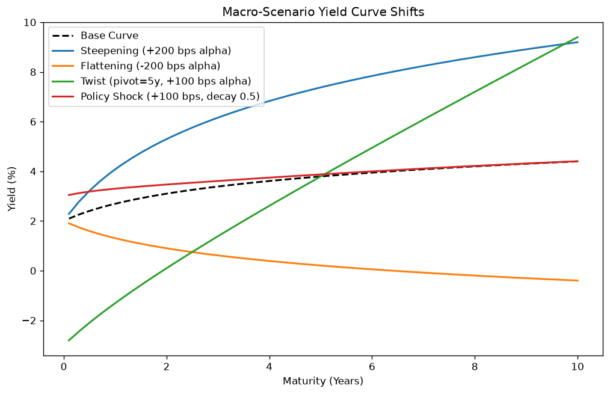

```python
from src.risk.scenario import ScenarioGenerator
import matplotlib.pyplot as plt
import numpy as np
from src.utils.plotting import set_theme

set_theme()


class DummyCurve:
    def __init__(self, tenors, yields):
        self.tenors = np.array(tenors)
        self.yields = np.array(yields)


# Base curve with a normal upward shape
tenors = np.linspace(0.1, 10, 50)
base_yields = 0.02 + 0.01 * np.log(1 + tenors)
base_curve = DummyCurve(tenors, base_yields)

generator = ScenarioGenerator()
steep_curve = generator.apply_non_parallel_shift(
    base_curve, shift_type="steepening", alpha=0.02
)
flat_curve = generator.apply_non_parallel_shift(
    base_curve, shift_type="flattening", alpha=0.02
)
twist_curve = generator.apply_non_parallel_shift(
    base_curve, shift_type="twist", alpha=0.01, pivot=5
)
shock_curve = generator.apply_policy_shock(base_curve, delta_r=0.01, decay=0.5)

plt.figure(figsize=(10, 6))
plt.plot(
    base_curve.tenors,
    base_curve.yields * 100,
    label="Base Curve",
    color="black",
    linestyle="--",
)
plt.plot(
    steep_curve.tenors, steep_curve.yields * 100, label="Steepening (+200 bps alpha)"
)
plt.plot(
    flat_curve.tenors, flat_curve.yields * 100, label="Flattening (-200 bps alpha)"
)
plt.plot(
    twist_curve.tenors,
    twist_curve.yields * 100,
    label="Twist (pivot=5y, +100 bps alpha)",
)
plt.plot(
    shock_curve.tenors,
    shock_curve.yields * 100,
    label="Policy Shock (+100 bps, decay 0.5)",
)
plt.title("Macro-Scenario Yield Curve Shifts")
plt.xlabel("Maturity (Years)")
plt.ylabel("Yield (%)")
plt.legend()
plt.show()
```

# Module 14: Structured Products & Correlation

```python
import sys
import os

sys.path.insert(0, os.path.abspath(".."))

import numpy as np
import matplotlib.pyplot as plt
from src.structured.copula import GaussianCopula  # noqa: E402
from src.structured.tranche import Tranche  # noqa: E402
from src.structured.cdo import SyntheticCDO  # noqa: E402

np.random.seed(42)
```

## 1. Tranche Sensitivities to Correlation (Correlation Smile)

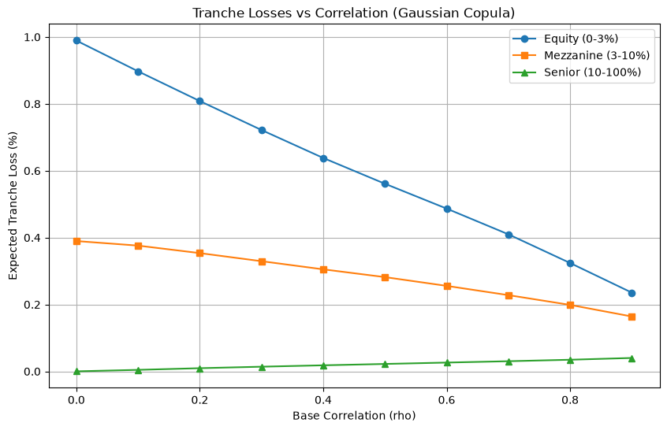

```python
n_credits = 100
hazard_rates = np.ones(n_credits) * 0.02  # 2% hazard rate
recovery_rate = 0.4
time_horizon = 5.0

tranches = [
    Tranche(0.0, 0.03, "Equity"),
    Tranche(0.03, 0.10, "Mezzanine"),
    Tranche(0.10, 1.0, "Senior"),
]

correlations = np.linspace(0.0, 0.9, 10)
equity_losses = []
mezzanine_losses = []
senior_losses = []

for rho in correlations:
    corr = np.eye(n_credits) * rho + (1 - rho) * np.eye(n_credits)
    corr[corr == 0] = rho

    copula = GaussianCopula(corr)
    cdo = SyntheticCDO(tranches, hazard_rates, recovery_rate)

    results = cdo.simulate_tranche_losses(copula, time_horizon, n_samples=5000, seed=42)

    equity_losses.append(results["Equity"]["expected_loss"])
    mezzanine_losses.append(results["Mezzanine"]["expected_loss"])
    senior_losses.append(results["Senior"]["expected_loss"])

plt.figure(figsize=(10, 6))
plt.plot(correlations, equity_losses, label="Equity (0-3%)", marker="o")
plt.plot(correlations, mezzanine_losses, label="Mezzanine (3-10%)", marker="s")
plt.plot(correlations, senior_losses, label="Senior (10-100%)", marker="^")
plt.xlabel("Base Correlation (rho)")
plt.ylabel("Expected Tranche Loss (%)")
plt.title("Tranche Losses vs Correlation (Gaussian Copula)")
plt.legend()
plt.grid(True)
plt.show()
```

## Floating Rate Notes (FRNs) (Module 45)

Demonstration of dynamic cash flow projection and discounting using discrete compounding.

```python
from src.structured.frn import FloatingRateNote
import numpy as np

frn = FloatingRateNote(
    notional=10_000_000,
    reference_rate=0.04,  # Flat 4% rate
    quoted_margin=0.015,  # 150 bps
    payment_frequency=4,
    maturity_years=5.0,
    has_floor=True,
    floor_rate=0.0,
)

# Price the FRN at a Discount Margin of 150 bps (should price near par)
price = frn.price(discount_margin=0.015)
print(f"FRN Price (Quoted Margin = Discount Margin): ${price:,.2f}")

# Price the FRN at a wider Discount Margin of 200 bps (should price at discount)
price_discount = frn.price(discount_margin=0.02)
print(f"FRN Price (Discount Margin = 200 bps): ${price_discount:,.2f}")
```

```
FRN Price (Quoted Margin = Discount Margin): $10,000,000.00
FRN Price (Discount Margin = 200 bps): $9,785,392.02
```

# Module 15: Advanced Interest Rate Exotics

This notebook verifies the mathematical correctness of our exotic interest rate models:

1. **LIBOR Market Model (LMM)**
2. **Constant Maturity Swaps (CMS)**
3. **Target Redemption Notes (TARN)**

```python
import numpy as np
import matplotlib.pyplot as plt
import sys

sys.path.append("../src")
from exotics.lmm import LiborMarketModel, SABRForwardMarketModel
from exotics.cms import ConstantMaturitySwap
from exotics.tarn import TargetRedemptionNote
```

## 1. LIBOR Market Model (LMM) with Predictor-Corrector

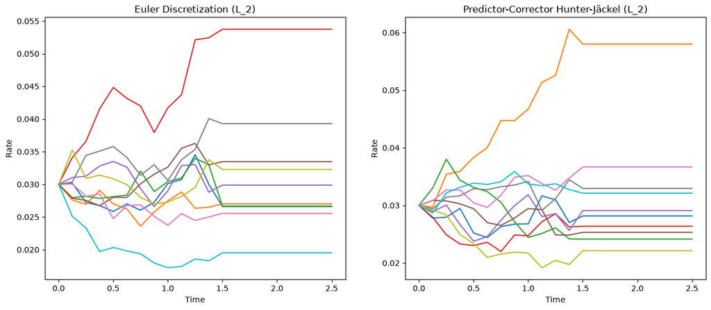

```python
forward_rates = [0.02, 0.025, 0.03, 0.035, 0.04]
tenors = [0.5, 1.0, 1.5, 2.0, 2.5, 3.0]
volatilities = [0.15, 0.18, 0.20, 0.22, 0.25]

# Create a simple correlation matrix (exponential decay)
corr = np.zeros((5, 5))
for i in range(5):
    for j in range(5):
        corr[i, j] = np.exp(-0.1 * abs(i - j))

lmm = LiborMarketModel(forward_rates, tenors, volatilities, corr)
paths_euler = lmm.simulate_spot_measure(dt=0.125, n_paths=1000, method="euler")
paths_pc = lmm.simulate_spot_measure(dt=0.125, n_paths=1000, method="pc")

fig, (ax1, ax2) = plt.subplots(1, 2, figsize=(15, 6))
for i in range(10):
    ax1.plot(np.linspace(0, 2.5, paths_euler.shape[1]), paths_euler[i, :, 2])
    ax2.plot(np.linspace(0, 2.5, paths_pc.shape[1]), paths_pc[i, :, 2])
ax1.set_title("Euler Discretization (L_2)")
ax2.set_title("Predictor-Corrector Hunter-Jäckel (L_2)")
for ax in (ax1, ax2):
    ax.set_xlabel("Time")
    ax.set_ylabel("Rate")
plt.show()
```

## 1b. Forward Market Model (FMM) and SABR-FMM

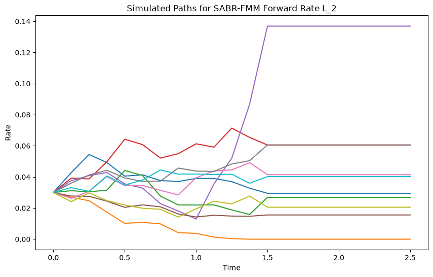

```python
alpha = [0.1, 0.1, 0.1, 0.1, 0.1]
beta = [0.5, 0.5, 0.5, 0.5, 0.5]
rho = [-0.3, -0.3, -0.3, -0.3, -0.3]
nu = [0.4, 0.4, 0.4, 0.4, 0.4]

sabr_fmm = SABRForwardMarketModel(forward_rates, tenors, alpha, beta, rho, nu, corr)
rates, alphas = sabr_fmm.simulate_spot_measure(dt=0.125, n_paths=100)

plt.figure(figsize=(10, 6))
for i in range(10):
    plt.plot(np.linspace(0, 2.5, rates.shape[1]), rates[i, :, 2])
plt.title("Simulated Paths for SABR-FMM Forward Rate L_2")
plt.xlabel("Time")
plt.ylabel("Rate")
plt.show()
```

## 2. Constant Maturity Swaps (CMS)

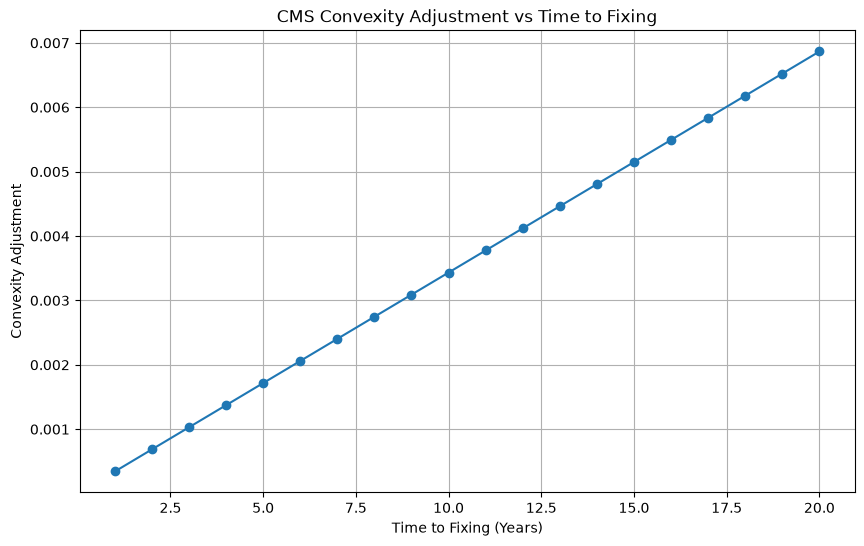

```python
cms = ConstantMaturitySwap(
    forward_swap_rate=0.05, swap_tenor_years=10, payment_frequency=2, volatility=0.20
)
times_to_fixing = np.linspace(1, 20, 20)
adjustments = [cms.convexity_adjustment(t) for t in times_to_fixing]

plt.figure(figsize=(10, 6))
plt.plot(times_to_fixing, adjustments, marker="o")
plt.title("CMS Convexity Adjustment vs Time to Fixing")
plt.xlabel("Time to Fixing (Years)")
plt.ylabel("Convexity Adjustment")
plt.grid(True)
plt.show()
```

## 3. Target Redemption Notes (TARN)

```python
# Simulate TARN pricing with random CMS rates
notional = 1_000_000
target_cap = 0.15  # 15% total

# Random CMS rates for paths
np.random.seed(42)
n_paths = 1000
n_periods = 10
simulated_cms = np.random.normal(loc=0.04, scale=0.01, size=(n_paths, n_periods))
simulated_cms = np.clip(simulated_cms, 0.0, None)


def coupon_rate_func(p, t_idx):
    # Coupon is max(CMS - 0.02, 0)
    return max(simulated_cms[p, t_idx] - 0.02, 0.0)


def funding_rate_func(_p, _t_idx):
    return 0.03  # constant discount


tarn = TargetRedemptionNote(notional, target_cap, coupon_rate_func, funding_rate_func)
price, stderr = tarn.price(
    n_paths=n_paths, payment_times=range(1, n_periods + 1), dt=1.0
)

print(f"TARN Price: {price:,.2f}")
print(f"Standard Error: {stderr:,.2f}")
```

```
TARN Price: 918,378.23
Standard Error: 1,020.82
```

# Module 16: XVA & Counterparty Credit Risk

This notebook verifies the implementation of the XVA mathematical models.

```python
import numpy as np
import matplotlib.pyplot as plt
from xva.exposure import simulate_exposures
from xva.xva import (
    calculate_cva,
    calculate_dva,
    calculate_fva,
    calculate_cva_wwr,
    calculate_kva,
)

np.random.seed(42)
```

## 1. Exposure Simulation

Simulate Mark-to-Market (MtM) paths and calculate EE, PFE (95%), and ENE.

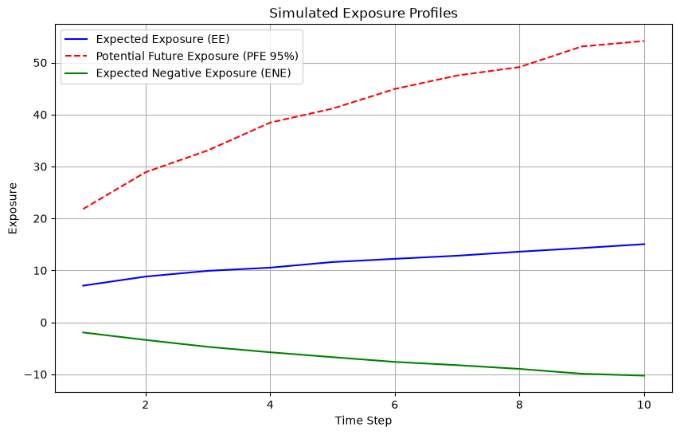

```python
num_paths = 1000
num_steps = 10

# Simulate Brownian motion for MtM
dt = 1.0
dw = np.random.normal(0, np.sqrt(dt), (num_paths, num_steps))
mtm_paths = np.cumsum(dw, axis=1) * 10 + 5.0  # drift and scale

ee, pfe, ene = simulate_exposures(mtm_paths)

time_grid = np.arange(1, num_steps + 1)

plt.figure(figsize=(10, 6))
plt.plot(time_grid, ee, label="Expected Exposure (EE)", color="blue")
plt.plot(
    time_grid,
    pfe,
    label="Potential Future Exposure (PFE 95%)",
    color="red",
    linestyle="--",
)
plt.plot(time_grid, ene, label="Expected Negative Exposure (ENE)", color="green")
plt.title("Simulated Exposure Profiles")
plt.xlabel("Time Step")
plt.ylabel("Exposure")
plt.legend()
plt.grid(True)
plt.show()
```

## 2. Value Adjustments (XVA)

Calculate CVA, DVA, and FVA using the simulated exposures.

```python
# Assumptions
pd = np.full(num_steps, 0.02)  # Marginal PD of counterparty
pd_own = np.full(num_steps, 0.015)  # Marginal PD of own firm
lgd = 0.6
lgd_own = 0.6
df = np.exp(-0.02 * time_grid)  # Discount factors
fca_spread = 0.015
fba_spread = 0.010

cva = calculate_cva(ee, pd, lgd, df)
dva = calculate_dva(ene, pd_own, lgd_own, df)
fva = calculate_fva(ee, ene, fca_spread, fba_spread, df, dt=dt)

print(f"Credit Valuation Adjustment (CVA): {cva:.2f}")
print(f"Debt Valuation Adjustment (DVA): {dva:.2f}")
print(f"Funding Valuation Adjustment (FVA): {fva:.2f}")
```

```
Credit Valuation Adjustment (CVA): 1.23
Debt Valuation Adjustment (DVA): 0.53
Funding Valuation Adjustment (FVA): 0.95
```

## 3. Margin Period of Risk (MPoR) & Initial Margin (IM)

Simulate collateralized exposures factoring in Variation Margin (VM) with a delay (MPoR) and Initial Margin.

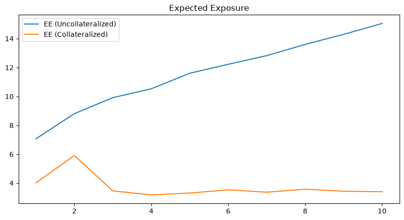

```python
im_paths = np.full((num_paths, num_steps), 5.0)
mpor_steps = 2
ee_col, pfe_col, ene_col = simulate_exposures(
    mtm_paths, mpor_steps=mpor_steps, im_paths=im_paths
)

plt.figure(figsize=(10, 5))
plt.plot(time_grid, ee, label="EE (Uncollateralized)")
plt.plot(time_grid, ee_col, label="EE (Collateralized)")
plt.title("Expected Exposure")
plt.legend()
plt.show()
```

## 4. Wrong-Way Risk (WWR)

Calculate CVA with Wrong-Way Risk (WWR) using a Gaussian copula to model correlation between exposure and probability of default.

```python
correlation = 0.5  # Positive correlation indicates WWR
positive_exposures = np.maximum(mtm_paths, 0)

cva_no_wwr = calculate_cva_wwr(positive_exposures, pd, lgd, df, 0.0)
cva_wwr = calculate_cva_wwr(positive_exposures, pd, lgd, df, correlation)

print(f"CVA (No WWR): {cva_no_wwr:.4f}")
print(f"CVA (WWR): {cva_wwr:.4f}")
```

```
CVA (No WWR): 1.2332
CVA (WWR): 3.3590
```

## 5. KVA & Funding Asymmetry

Calculate Capital Valuation Adjustment (KVA) and Funding Valuation Adjustment (FVA) with asymmetric spreads.

```python
# Asymmetric funding spreads over time
fca_spread_asym = np.linspace(0.015, 0.020, num_steps)
fba_spread_asym = np.linspace(0.010, 0.012, num_steps)

fva_asym = calculate_fva(ee, ene, fca_spread_asym, fba_spread_asym, df, dt)
print(f"FVA (Asymmetric): {fva_asym:.4f}")

# Capital Paths for KVA
capital_paths = np.linspace(50.0, 10.0, num_steps)  # declining capital
cost_of_capital = 0.10

kva = calculate_kva(capital_paths, cost_of_capital, df, dt)
print(f"KVA: {kva:.4f}")
```

```
FVA (Asymmetric): 1.1590
KVA: 27.5770
```